# Analyzing American Time Use Surveys in R

An Example: Mothers’ Time Use by Marital Status

Joanna R. Pepin

05 February, 2019

# Getting the data

This tutorial uses data downloaded from IPUMS’ [ATUS-X](https://www.atusdata.org/atus/) extract builder. The data includes samples from 2003 - 2017.

## Variables:

| Type | Variable | Label |
| --- | --- | --- |
| H | RECTYPE | Record Type |
| H | YEAR | Survey year |
| H | CASEID | ATUS Case ID |
| H | REGION | Region |
| H | HH_SIZE | Number of people in household |
| H | HH_CHILD | Children under 18 in household |
| H | HH_NUMKIDS | Number of children under 18 in household |
| H | AGEYCHILD | Age of youngest household child |
| H | HH_NUMADULTS | Number of adults in household |
| P | PERNUM | Person number (general) |
| P | LINENO | Person line number |
| P | DAY | ATUS interview day of the week |
| P | WT06 | Person weight, 2006 methodology |
| P | AGE | Age |
| P | SEX | Sex |
| P | RACE | Race |
| P | HISPAN | Hispanic origin |
| P | MARST | Marital status |
| P | EDUC | Highest level of school completed |
| P | FULLPART | Full time/part time employment status |
| P | SPOUSEPRES | Spouse or unmarried partner in household |
| P | HH_NUMOWNKIDS | Number of own children under 18 in household |
| P | KIDUND13 | Own child under 13 in household |
| A | ACTLINE | Activity line number |
| A | ACTIVITY | Activity |
| A | DURATION | Duration of activity |
| A | START | Activity start time |
| A | STOP | Activity stop time |

Additionally, two time use variables were constructed in ATUSX:

- The *telesolo* is a constructed time use variable from activity codes 120303 & 120304 conducted while *alone*.
- The *telesp* is a constructed time use variable from activity codes 120303 & 120304 conducted with a *spouse* or *unmarried partner* present.

Extract Notes:

- DATA FORMAT: .dat (fixed-width text)
- STRUCTURE: Hierarchical
- SAMPLE MEMBERS: Respondents

## Data Download and Import

IPUMS NOTE: To load data, you must download both the extract’s data and the DDI.  
Download the .DAT file after ATUSX processes your request (you will get an email).  
To download the DDI file, right click on the DDI link under the CODEBOOK heading, and select “save link file as”

Detailed instructions for importing the data can be found at: https://cran.r-project.org/web/packages/ipumsr/vignettes/ipums.html.

This R code was executed in the open source edition of [RStudio](https://www.rstudio.com/products/RStudio/).

### Set the working directory file path

You will need to change your file path to the local folder where you saved the ATUS data extracts.  
Notice the “/” lean to the right and not the left () if you are using a Windows computer.

```r
setwd("C:/Users/Joanna/Dropbox/MaritalStatus")
```

### Load the libraries

```r
library(ipumsr)
library(tidyverse)
```

Libraries can be installed with the commands `install.packages("ipumsr")` and `install.packages("tidyverse")`. These only need to be installed once but users must load the libraried each time Rstudio is started.

### Load ATUS Data into R

Users should change the `"atus_00026.xml"` to the file name of their own ATUSX extract.

```r
ddi <- read_ipums_ddi("atus_00026.xml")
data <- read_ipums_micro(ddi)
```

```
## Use of data from ATUS-X is subject to conditions including that users should
## cite the data appropriately. Use command `ipums_conditions()` for more details.
```

# Set-up the Data

## Overview of the data

```r
# Make sure data is now a dataframe.
class(data)

#Look at the structure of the data
summary(data)

# Check-out the variable names
names(data)
```

```r
# Make the variable names lowercase
data <- data %>% rename_all(tolower)
```

### Change the variables’ class from labelled to integer, character, or factor

```r
data <- data %>%
  mutate( year       = as.integer(lbl_clean(year)),
          caseid     = as.character(lbl_clean(caseid)),
          hh_size    = as.integer(lbl_clean(hh_size)),
          hh_child   = as.integer(lbl_clean(hh_child)),
          hh_numkids = as.integer(lbl_clean(hh_numkids)),
          ageychild  = as.integer(lbl_clean(ageychild)),
          hh_numadults = as.integer(lbl_clean(hh_numadults)),
          day        = as_factor(lbl_clean(day)),
          wt06       = as.integer(lbl_clean(wt06)),
          age        = as.integer(lbl_clean(age)),
          sex        = as_factor(lbl_clean(sex)),
          race       = as_factor(lbl_clean(race)),
          hispan     = as_factor(lbl_clean(hispan)),
          marst      = as_factor(lbl_clean(marst)),
          educ       = as.integer(lbl_clean(educ)),
          fullpart   = as.character(lbl_clean(fullpart)),
          spousepres = as_factor(lbl_clean(spousepres)),
          hh_numownkids = as.integer(lbl_clean(hh_numownkids)),
          kidund13   = as_factor(lbl_clean(kidund13)),
          activity   = as.character(lbl_clean(activity)),
          region     = as_factor(lbl_clean(region)),
          telesolo   = as.integer(lbl_clean(telesolo)),
          telesp     = as.integer(lbl_clean(telesp)))
```

### Prepare duration and activity variables

```r
# Change NA to 0 for duration & activity minutes
data[["duration"]][is.na(data[["duration"]])] <- 0
summary(data$duration)

data[["activity"]][is.na(data[["activity"]])] <- "0"
summary(data$activity)
```

```r
# Check that duration = 1440
data %>%
  group_by(caseid) %>%
  summarise(total= sum(duration))
```

```
## # A tibble: 191,558 x 2
##    caseid         total
##    <chr>          <dbl>
##  1 20030100013280  1440
##  2 20030100013344  1440
##  3 20030100013352  1440
##  4 20030100013848  1440
##  5 20030100014165  1440
##  6 20030100014169  1440
##  7 20030100014209  1440
##  8 20030100014427  1440
##  9 20030100014550  1440
## 10 20030100014758  1440
## # ... with 191,548 more rows
```

# Create activity variables by person

## Create the activity variable components

This creates a logical object in RStudio for each activity category.  
The activity codes can be found in ATUS’[Activity Coding Lexicon](https://www.bls.gov/tus/lexiconnoex0317.pdf).

```r
# Childcare
ccare <- data$activity %in% c(
  "30101" , "30102" ,   "30103" ,   "30104" ,   "30105" ,   "30108" ,   "30109" ,   "30110" ,
  "30111" , "30112" ,   "30199" ,   "30201" ,   "30202" ,   "30203" ,   "30204" ,   "30299" ,
  "30301" , "30302" ,   "30303" ,   "30399" ,   "30186")

# Housework
hswrk <- data$activity %in% c(
  "20101" , "20102" ,   "20103" ,   "20104" ,   "20199")

# Leisure
leisure <- data$activity %in% c(
  "120101" , "120199" , "120201" ,  "120202" ,  "120299" ,  "120401" ,  "120402" ,  "120403" ,
  "120404" , "120405" , "120499" ,  "120501" ,  "120502" ,  "120504" ,  "120599" ,  "130201" ,
  "130202" , "130203" , "130204" ,  "130205" ,  "130206" ,  "130207" ,  "130208" ,  "130209" ,
  "130210" , "130211" , "130212" ,  "130213" ,  "130214" ,  "130215" ,  "130216" ,  "130217" ,
  "130218" , "130219" , "130220" ,  "130221" ,  "130222" ,  "130223" ,  "130224" ,  "130225" ,
  "130226" , "130227" , "130228" ,  "130229" ,  "130230" ,  "130231" ,  "130232" ,  "130299" ,
  "130302" , "130402" , "120307" ,  "120309" ,  "120310" ,  "120311" ,  "120312" ,  "120313" ,
  "130101" , "130102" , "130103" ,  "130104" ,  "130105" ,  "130106" ,  "130107" ,  "130108" ,
  "130109" , "130110" , "130111" ,  "130112" ,  "130113" ,  "130114" ,  "130115" ,  "130116" ,
  "130117" , "130118" , "130119" ,  "130120" ,  "130121" ,  "130122" ,  "130123" ,  "130124" ,
  "130125" , "130126" , "130127" ,  "130128" ,  "130129" ,  "130130" ,  "130131" ,  "130132" ,
  "130133" , "130134" , "130135" ,  "130136" ,  "130199" ,  "130201" ,  "130301" ,  "130401" ,
  "130499" , "120301" , "120302" ,  "120303" ,  "120304" ,  "120305" ,  "120306" ,  "120308" ,
  "120399" , "120503" , "129999" ,  "130399" ,  "139999" ,  "160101" ,  "160102" ,  "181201" ,
  "181202" , "181204" , "181283" ,  "181299" ,  "181301" ,  "181302" ,  "181399")

# Sleep
sleep <- data$activity %in% c(
  "10101" , "10102" ,  "10199")

#Leisure sub-types
socl <- data$activity %in% c(
  "120101" , "120199"  ,  "120201" ,  "120202" ,  "120299" ,  "120401" ,  "120402" ,  "120403" ,
  "120404" , "120405"  ,    "120499" ,  "120501" ,  "120502" ,  "120504" ,  "120599" ,  "130201" ,
  "130202" , "130203"  ,    "130204" ,  "130205" ,  "130206" ,  "130207" ,  "130208" ,  "130209" ,
  "130210" , "130211"  ,    "130212" ,  "130213" ,  "130214" ,  "130215" ,  "130216" ,  "130217" ,
  "130218" , "130219"    ,  "130220" ,  "130221" ,  "130222" ,  "130223" ,  "130224" ,  "130225" ,
  "130226" , "130227"  ,    "130228" ,  "130229" ,  "130230" ,  "130231" ,  "130232" ,  "130299" ,
  "130302" , "130402")

actl   <- data$activity %in% c(
  "120307" ,    "120309" ,  "120310" ,  "120311" ,  "120312" ,  "120313" ,  "130101" ,  "130102" ,
  "130103" ,    "130104" ,  "130105" ,  "130106" ,  "130107" ,  "130108" ,  "130109" ,  "130110" ,
  "130111" ,    "130112" ,  "130113" ,  "130114" ,  "130115" ,  "130116" ,  "130117" ,  "130118" ,
  "130119" ,    "130120" ,  "130121" ,  "130122" ,  "130123" ,  "130124" ,  "130125" ,  "130126" ,
  "130127" ,    "130128" ,  "130129" ,  "130130" ,  "130131" ,  "130132" ,  "130133" ,  "130134" ,
  "130135" ,    "130136" ,  "130199" ,  "130201" ,  "130301" ,  "130401" ,  "130499")

pass   <- data$activity %in% c(
  "120301" ,    "120302" ,  "120303" ,  "120304" ,  "120305" ,  "120306" ,  "120308" ,  "120399" ,
  "120503")

# Television
tele   <- data$activity %in% c(
  "120303" , "120304")
```

## Create the activity identification variables in the dataset

Next, we use those logical objects to create the activity category variables in our dataset. First, we create a new variable called “actcat”, with missing values. This variable will identify the activity categories, using the logical objects we created.

```r
data$actcat<-NA
data$actcat[ccare]   <- "child care"
data$actcat[hswrk]   <- "housework"
data$actcat[leisure] <- "leisure"
data$actcat[sleep]   <- "sleep"
data$actcat <- as.character(data$actcat)
```

We’ll also create a leisure category variable and one for television. Sub-categories of activties need their own variables. Here, television is a subcategory of passive leisure, which is a subcategory of leisure. Thus, we have more refined identification separated into different variables.

```r
data$leiscat<-NA
data$leiscat[socl] <- "social leisure"
data$leiscat[actl] <- "active leisure"
data$leiscat[pass] <- "passive leisure"
data$leiscat <- as.character(data$leiscat)

data$telecat<-NA
data$telecat[tele] <- "television"
data$telecat <- as.character(data$telecat)
```

New Activity Category Variables.

| caseid | activity | duration | actcat | leiscat | telecat |
| --- | --- | --- | --- | --- | --- |
| 20030100013280 | 0 | 0 | NA | NA | NA |
| 20030100013280 | 0 | 0 | NA | NA | NA |
| 20030100013280 | 130124 | 60 | leisure | active leisure | NA |
| 20030100013280 | 0 | 0 | NA | NA | NA |
| 20030100013280 | 10201 | 30 | NA | NA | NA |
| 20030100013280 | 0 | 0 | NA | NA | NA |
| 20030100013280 | 10101 | 600 | sleep | NA | NA |
| 20030100013280 | 0 | 0 | NA | NA | NA |
| 20030100013280 | 120303 | 150 | leisure | passive leisure | television |
| 20030100013280 | 0 | 0 | NA | NA | NA |
| 20030100013280 | 110101 | 5 | NA | NA | NA |
| 20030100013280 | 0 | 0 | NA | NA | NA |
| 20030100013280 | 120303 | 175 | leisure | passive leisure | television |
| 20030100013280 | 0 | 0 | NA | NA | NA |
| 20030100013280 | 10101 | 270 | sleep | NA | NA |
| 20030100013280 | 0 | 0 | NA | NA | NA |
| 20030100013280 | 10201 | 10 | NA | NA | NA |
| 20030100013280 | 0 | 0 | NA | NA | NA |
| 20030100013280 | 130124 | 140 | leisure | active leisure | NA |
| 20030100013280 | 0 | 0 | NA | NA | NA |

## Duration variables

Next we need to create summary variables with the total duration of each activty for each person

```r
# Master activty variables
data <- data %>%
  group_by(caseid) %>%
  summarise (leisure  = sum(duration[actcat ==  "leisure"],    na.rm=TRUE),
             sleep    = sum(duration[actcat ==  "sleep"],      na.rm=TRUE),
             hswrk    = sum(duration[actcat ==  "housework"],  na.rm=TRUE),
             ccare    = sum(duration[actcat ==  "child care"], na.rm=TRUE)) %>%
  inner_join(data, by='caseid')

# Leisure activity variables
data <- data %>%
  group_by(caseid) %>%
  summarise (socl     = sum(duration[leiscat ==  "social leisure"],      na.rm=TRUE),
             actl     = sum(duration[leiscat ==  "active leisure"],      na.rm=TRUE),
             pass     = sum(duration[leiscat ==  "passive leisure"],     na.rm=TRUE)) %>%
  inner_join(data, by='caseid')

# Television variables
data <- data %>%
  group_by(caseid) %>%
  summarise (tele     = sum(duration[telecat ==  "television"],          na.rm=TRUE)) %>%
  inner_join(data, by='caseid')
```

New Activity Summary Variables.

| caseid | leisure | sleep | hswrk | ccare | socl | actl | pass | tele |
| --- | --- | --- | --- | --- | --- | --- | --- | --- |
| 20030100013280 | 525 | 870 | 0 | 0 | 0 | 200 | 325 | 325 |
| 20030100013280 | 525 | 870 | 0 | 0 | 0 | 200 | 325 | 325 |
| 20030100013280 | 525 | 870 | 0 | 0 | 0 | 200 | 325 | 325 |
| 20030100013280 | 525 | 870 | 0 | 0 | 0 | 200 | 325 | 325 |
| 20030100013280 | 525 | 870 | 0 | 0 | 0 | 200 | 325 | 325 |

# Create tidy data

Currently, the data is in long format, with each person represented in multiple rows in the dataset. We will aggregate the data so each person is represented once per row.

Long format.

| caseid | pernum | lineno | sex | actline | activity | sleep |
| --- | --- | --- | --- | --- | --- | --- |
| 20030100013280 | NA | NA | NA | NA | 0 | 870 |
| 20030100013280 | 1 | 1 | Male | NA | 0 | 870 |
| 20030100013280 | NA | NA | NA | 1 | 130124 | 870 |
| 20030100013280 | NA | NA | NA | NA | 0 | 870 |
| 20030100013280 | NA | NA | NA | 2 | 10201 | 870 |
| 20030100013280 | NA | NA | NA | NA | 0 | 870 |
| 20030100013280 | NA | NA | NA | 3 | 10101 | 870 |
| 20030100013280 | NA | NA | NA | NA | 0 | 870 |
| 20030100013280 | NA | NA | NA | 4 | 120303 | 870 |
| 20030100013280 | NA | NA | NA | NA | 0 | 870 |

Create a summary dataset for the variables that repeat each row, per person

```r
max <- data %>%
  group_by(caseid) %>%
  summarise_at(vars(tele, socl, actl, pass, ccare, hswrk, leisure, sleep, year), funs(max))
```

Notice that each person is now represented only once per row.

```
## # A tibble: 5 x 9
##   caseid          tele  socl  actl  pass ccare hswrk leisure sleep
##   <chr>          <dbl> <dbl> <dbl> <dbl> <dbl> <dbl>   <dbl> <dbl>
## 1 20030100013280   325     0   200   325     0     0     525   870
## 2 20030100013344    60   530     0    60    60     0     610   620
## 3 20030100013352   120   220     0   120     0    15     340   560
## 4 20030100013848   265     0     0   265     5     0     265   720
## 5 20030100014165    60     0    60    60   120     0     130   385
```

Create a summary dataset for the variables that appear in the first row only, by person

```r
rec1 <- data %>%
  group_by(caseid) %>%
  summarise_at(vars(hh_size, hh_child, hh_numkids, ageychild, hh_numadults, region), funs(first))
```

```
## # A tibble: 5 x 7
##   caseid         hh_size hh_child hh_numkids ageychild hh_numadults region
##   <chr>            <int>    <int>      <int>     <int>        <int> <fct>
## 1 20030100013280       3        0          0       999            3 West
## 2 20030100013344       4        1          2         0            2 West
## 3 20030100013352       2        0          0       999            2 West
## 4 20030100013848       4        1          2         9            2 South
## 5 20030100014165       4        1          2        14            2 South
```

Create a summary dataset for the variables that appear in the second row only, by person

```r
rec2 <- data %>%
  group_by(caseid) %>%
  summarise_at(vars(age, sex, race, hispan, marst, educ, fullpart, spousepres,
                     hh_numownkids, kidund13, day, wt06, telesolo, telesp), funs(nth(., 2)))
```

```
## # A tibble: 5 x 15
##   caseid   age sex   race  hispan marst  educ fullpart spousepres
##   <chr>  <int> <fct> <fct> <fct>  <fct> <int> <chr>    <fct>
## 1 20030~    60 Male  Blac~ Not H~ Marr~    41 2        Spouse pr~
## 2 20030~    41 Fema~ Whit~ Not H~ Marr~    30 2        Spouse pr~
## 3 20030~    26 Fema~ Whit~ Not H~ Marr~    31 2        Spouse pr~
## 4 20030~    36 Fema~ Blac~ Not H~ Marr~    21 99       Spouse pr~
## 5 20030~    51 Male  Whit~ Not H~ Marr~    42 1        Spouse pr~
## # ... with 6 more variables: hh_numownkids <int>, kidund13 <fct>,
## #   day <fct>, wt06 <int>, telesolo <int>, telesp <int>
```

Put them all together.

```r
atus <- reduce(list(max, rec1, rec2),
               left_join, by = "caseid")
```

Take a look at the person-level file with activity duration summary variables

```
## # A tibble: 5 x 30
##   caseid  tele  socl  actl  pass ccare hswrk leisure sleep  year hh_size
##   <chr>  <dbl> <dbl> <dbl> <dbl> <dbl> <dbl>   <dbl> <dbl> <dbl>   <int>
## 1 20030~   325     0   200   325     0     0     525   870  2003       3
## 2 20030~    60   530     0    60    60     0     610   620  2003       4
## 3 20030~   120   220     0   120     0    15     340   560  2003       2
## 4 20030~   265     0     0   265     5     0     265   720  2003       4
## 5 20030~    60     0    60    60   120     0     130   385  2003       4
## # ... with 19 more variables: hh_child <int>, hh_numkids <int>,
## #   ageychild <int>, hh_numadults <int>, region <fct>, age <int>,
## #   sex <fct>, race <fct>, hispan <fct>, marst <fct>, educ <int>,
## #   fullpart <chr>, spousepres <fct>, hh_numownkids <int>, kidund13 <fct>,
## #   day <fct>, wt06 <int>, telesolo <int>, telesp <int>
```

# Transform variables

```r
# Gender
levels(atus$sex) <- c('Men', 'Women')

# Age
summary(atus$age)

# Marital status
  # cohabitors in one group regardless of marital history
  # use spousepres variable as indicator of marital status at time of ATUS diary
atus <- atus %>%
  mutate(
    mar = case_when(
      spousepres == "Spouse present"                                                         ~ "Married",
      spousepres == "Unmarried partner present"                                              ~ "Cohabiting",
      marst      == "Never married" & spousepres == "No spouse or unmarried partner present" ~ "Single",
      marst      != "Widowed" & marst != "Never married" &
      spousepres == "No spouse or unmarried partner present"                                 ~ "Divorced/Separated",
      TRUE                                                                                   ~  NA_character_
    ))
atus$mar <- as_factor(atus$mar, levels = c("Married", "Cohabiting", "Single", "Divorced/Separated", ordered = TRUE))

# Extended Family Member
atus <- atus %>%
  mutate(
    exfam = case_when(
      ((spousepres == "Spouse present" | spousepres == "Unmarried partner present") & hh_numadults <= 2) |
      ((spousepres == "No spouse or unmarried partner present") & hh_numadults <=1) ~ "No extra adults",
      ((spousepres == "Spouse present" | spousepres == "Unmarried partner present") & hh_numadults >= 3) |
      ((spousepres == "No spouse or unmarried partner present") & hh_numadults >=2) ~ "Extra adults",
      TRUE                        ~  NA_character_
    ))
atus$exfam <- as_factor(atus$exfam, levels = c("No extra adults", "Extra adults"))
atus$exfam <- relevel(atus$exfam, ref = "No extra adults")

#Kid under 2
atus <- atus %>%
  mutate(
    kidu2 = case_when(
     ageychild <=2 ~ "Child < 2",
     TRUE          ~ "No children < 2"
    ))
atus$kidu2 <- as_factor(atus$kidu2, levels = c("Child < 2", "No children < 2", ref = "No children < 2"))

# Number of own HH kids
summary(atus$hh_numownkids)

# Employment
atus <- atus %>%
  mutate(
    employ = case_when(
     fullpart == "1"  ~ "Full-time",
     fullpart == "2"  ~ "Part-time",
     fullpart == "99" ~ "Not employed",
     TRUE             ~  NA_character_
    ))
atus$employ <- as_factor(atus$employ, levels = c("Full-time", "Part-time", "Not employed"))


# Education
atus <- atus %>%
  mutate(
    educ = case_when(
      (educ >= 10 & educ <= 17)   ~ "Less than high school",
      (educ >= 20 & educ <= 21)   ~ "High school",
      (educ >= 30 & educ <= 31)   ~ "Some college",
      (educ >= 40 & educ <= 43)   ~ "BA or higher",
      TRUE                        ~  NA_character_
    ))
atus$educ <- as_factor(atus$educ, levels = c("Less than high school", "High school", "Some college", "BA or higher", ref = "High school"))

# Race
atus <- atus %>%
  mutate(
    raceth = case_when(
      race   == "White only" & hispan == "Not Hispanic"  ~ "White",
      race   == "Black only" & hispan == "Not Hispanic"  ~ "Black",
      race   == "Asian only" & hispan == "Not Hispanic"  ~ "Asian",
      hispan != "Not Hispanic"                           ~ "Hispanic",
      TRUE                                               ~ "Other"
    ))
atus$raceth <- as_factor(atus$raceth, levels = c("White", "Black", "Hispanic", "Asian", "Other"))
atus$raceth <- relevel(atus$raceth, ref = "White")

# Weekend
atus <- atus %>%
  mutate(
    weekend = case_when(
      day == "Sunday"   | day == "Saturday"     ~ "Weekend",
      day == "Monday"   | day == "Tuesday" | day == "Wednesday" |
      day == "Thursday" | day == "Friday"       ~ "Weekday",
      TRUE              ~  NA_character_
    ))
atus$weekend <- as_factor(atus$weekend, levels = c("Weekday", "Weekend"))
atus$weekend <- relevel(atus$weekend, ref = "Weekday")

# Region
summary(atus$region)
```

## Sample selection

Limit the dataset to White, Black, and Hispanic mothers of children with kids 13 or younger.  
Let’s also restict the dataset to mothers who are prime working age.

```r
atus <- filter(atus, sex == "Women") # women
atus <- filter(atus, hh_numownkids >=1) # mothers
atus <- filter(atus, ageychild <=13) #mothers of kids 13 or younger
atus <- filter(atus, age >= 18 & age <=54) #prime working age
atus <- filter(atus, raceth != "Asian" & raceth != "Other") # white, black, and Hispanic
```

## Use listwise deletion to deal with missing data

```r
# Keep only the variables of interest
atus <- select(atus, caseid, wt06, year, ccare, hswrk, leisure, sleep, socl, actl, pass, tele, telesolo, telesp, age, sex, mar, exfam, kidu2, hh_numownkids, employ, educ, raceth, weekend, region)
# Listwise deletion
atus <- na.omit(atus)
```

Here’s a look at the data

```
## Classes 'tbl_df', 'tbl' and 'data.frame':    30645 obs. of  24 variables:
##  $ caseid       : chr  "20030100013344" "20030100013848" "20030100014209" "20030100014550" ...
##  $ wt06         : int  1735322 6622022 1637826 1528296 4277052 505227 1058351 3594555 2574209 2720948 ...
##  $ year         : num  2003 2003 2003 2003 2003 ...
##  $ ccare        : num  60 5 98 0 80 60 62 105 378 36 ...
##  $ hswrk        : num  0 0 0 200 10 10 0 60 180 0 ...
##  $ leisure      : num  610 265 0 120 542 175 113 180 197 131 ...
##  $ sleep        : num  620 720 531 645 180 575 570 630 480 495 ...
##  $ socl         : num  530 0 0 0 90 0 0 120 165 0 ...
##  $ actl         : num  0 0 0 0 150 0 30 60 30 0 ...
##  $ pass         : num  60 265 0 120 267 175 83 0 0 131 ...
##  $ tele         : num  60 265 0 120 0 175 83 0 0 111 ...
##  $ telesolo     : int  0 0 0 0 0 0 30 0 0 98 ...
##  $ telesp       : int  60 265 0 120 0 0 53 0 0 0 ...
##  $ age          : int  41 36 44 33 39 33 32 45 39 25 ...
##  $ sex          : Factor w/ 2 levels "Men","Women": 2 2 2 2 2 2 2 2 2 2 ...
##  $ mar          : Factor w/ 4 levels "Married","Cohabiting",..: 1 1 1 1 1 3 1 1 4 4 ...
##  $ exfam        : Factor w/ 2 levels "No extra adults",..: 1 1 1 1 1 1 1 1 1 1 ...
##  $ kidu2        : Factor w/ 2 levels "No children < 2",..: 2 1 1 1 1 1 2 1 2 1 ...
##  $ hh_numownkids: int  2 2 1 3 4 1 1 2 2 1 ...
##  $ employ       : Factor w/ 3 levels "Part-time","Not employed",..: 1 2 3 3 3 3 3 3 1 3 ...
##  $ educ         : Factor w/ 4 levels "BA or higher",..: 2 3 3 2 2 2 1 1 2 3 ...
##  $ raceth       : Factor w/ 5 levels "White","Black",..: 1 2 1 1 2 1 1 1 2 1 ...
##  $ weekend      : Factor w/ 2 levels "Weekday","Weekend": 2 1 1 2 1 2 2 1 1 1 ...
##  $ region       : Factor w/ 4 levels "Northeast","Midwest",..: 4 3 3 2 1 3 1 3 2 2 ...
##  - attr(*, "na.action")= 'omit' Named int  46 50 64 83 93 132 133 142 156 159 ...
##   ..- attr(*, "names")= chr  "46" "50" "64" "83" ...
```

# Create Linear Models and Margins

Load the `ggeffects` package in order to compute marginal effects from statistical models and save the results as tidy data frames.

```r
library(ggeffects)
```

For each of activity variables of interest, run a linear model (`lm`) and then calculate the marginal effects (`ggeffect`)  
`ggeffect` calculates the adjusted predictions at the means, using proportions to fix factors

```r
#Childcare
lm_care <- lm(ccare   ~ mar + exfam + hh_numownkids + kidu2 + educ + employ + raceth + age + weekend + region , data = atus, weight=wt06)
pcare   <- ggeffect(lm_care, terms = "mar")

#Housework
lm_hswrk <- lm(hswrk  ~ mar + exfam + hh_numownkids + kidu2 + educ + employ + raceth + age + weekend + region , data = atus, weight=wt06)
phswrk   <- ggeffect(lm_hswrk, terms = "mar")

#Leisure
lm_leis <- lm(leisure ~ mar + exfam + hh_numownkids + kidu2 + educ + employ + raceth + age + weekend + region , data = atus, weight=wt06)
pleis   <- ggeffect(lm_leis, terms = "mar")

#Sleep
lm_sleep <- lm(sleep  ~ mar + exfam + hh_numownkids + kidu2 + educ + employ + raceth + age + weekend + region , data = atus, weight=wt06)
psleep   <- ggeffect(lm_sleep, terms = "mar")
```

## Combine predictions into one dataframe

For each of the marginal effects datasets, label the group values as the activity

```r
levels(pcare$group)[levels(pcare$group)=="1"]   <- "Childcare"
levels(phswrk$group)[levels(phswrk$group)=="1"] <- "Housework"
levels(pleis$group)[levels(pleis$group)=="1"]   <- "Leisure"
levels(psleep$group)[levels(psleep$group)=="1"] <- "Sleep"
```

Maniuplate the marital status variable

```r
# Change the variable to be a factor variable from numeric
pcare$x <- as.factor(pcare$x)
phswrk$x <- as.factor(phswrk$x)
pleis$x <- as.factor(pleis$x)
psleep$x <- as.factor(psleep$x)
```

Combine the datatables

```r
pred <- rbind(pcare, phswrk, pleis, psleep)
```

Prepare the categorical variables for data visualization

```r
# Revalue the marital status factors to be readable
levels(pred$x)[levels(pred$x)=="3"] <- "Married"
levels(pred$x)[levels(pred$x)=="1"] <- "Cohabiting"
levels(pred$x)[levels(pred$x)=="4"] <- "Single"
levels(pred$x)[levels(pred$x)=="2"] <- "Divorced/Separated"

# Order the marital status and activity factors
pred$x     <- ordered(pred$x, levels = c("Married", "Cohabiting", "Single", "Divorced/Separated"))
pred$group <- ordered(pred$group, levels = c("Childcare", "Housework", "Leisure", "Sleep"))
```

Calculate the difference variable (mothers time use compared to married mothers time use, by activity)

```r
pred <- pred %>%
  group_by(group) %>%
  mutate(diff = predicted - predicted[x == "Married"])
```

# Data visualization

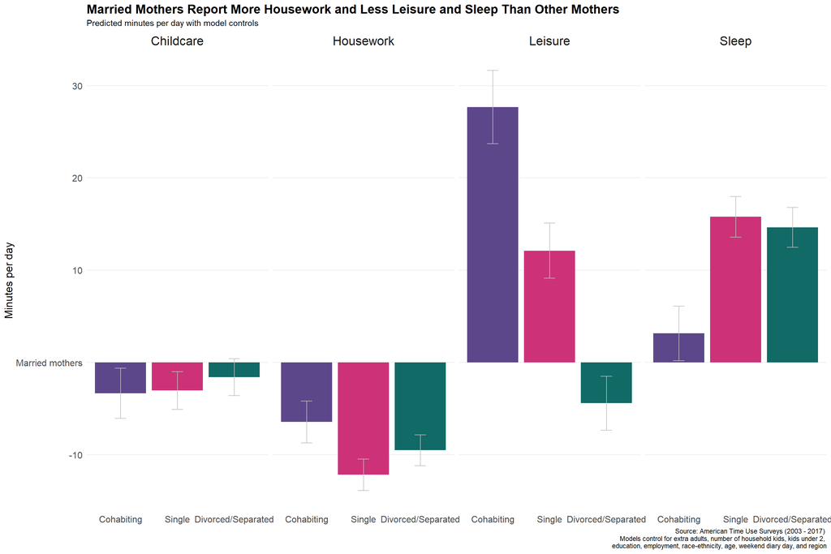

```r
pred %>%
  filter(x != "Married") %>%
  ggplot(aes(x, diff, fill = x, label = round(diff, 0))) +
  geom_col() +
  facet_grid(~group) +
  ggtitle("Married Mothers Report More Housework and Less Leisure and Sleep Than Other Mothers") +
  labs(x = NULL, y = "Minutes per day", subtitle = "Predicted minutes per day with model controls",
       caption = "Source: American Time Use Surveys (2003 - 2017) \n Models control for extra adults, number of household kids, kids under 2, \n education, employment, race-ethnicity, age, weekend diary day, and region") +
  theme_minimal() +
  theme(plot.subtitle = element_text(size = 11, vjust = 1),
        plot.caption  = element_text(vjust = 1),
        legend.position="none",
        strip.text.x  = element_text(size = 16),
        axis.title    = element_text(size = 14),
        axis.text     = element_text(size = 12),
        plot.title    = element_text(size = 16, face = "bold"),
        panel.grid.minor = element_blank(),
        panel.grid.major.x = element_blank()) +
  scale_y_continuous(breaks = c(-10, 0, 10, 20, 30), labels=c("-10", "Married mothers", "10", "20", "30")) +
  scale_fill_manual(values=c("#5D478B", "#CD3278", "#116A66")) +
  geom_errorbar(aes(ymin=diff-std.error, ymax=diff+std.error), width=.2,
                position=position_dodge(.9), color="grey")
```